# Analysis of COVID-19 Hospitalizations and Race

Erin Tsai

5/13/2021

### Introduction

Patients from certain demographic groups may be at higher risk for the coronavirus disease 2019 (COVID-19). The objective is to investigate if patients in a particular racial demographic are at an increased risk for COVID-19 infection compared to other racial demographics, specifically using hospitalization data from the CDC. And also to investigate if age is shown to have increased risk with increasing age.

### Results

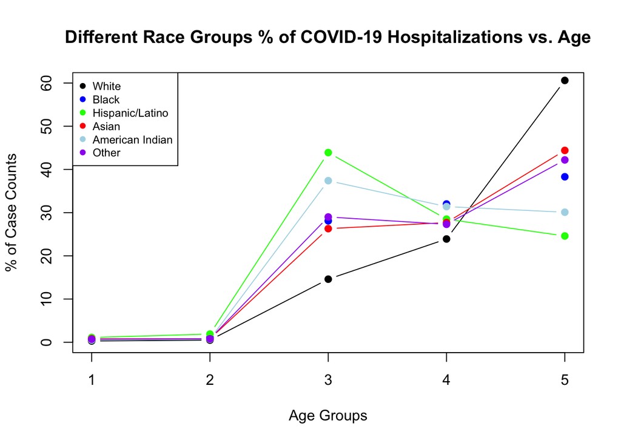

```r
plot(covid_white$Age.Group, (covid_white$Percent), type = "b", xlab = "Age Groups", ylab = "% of Case Counts", ylim = c(0,60), pch = 19, main = "Different Race Groups % of COVID-19 Hospitalizations vs. Age")
points(covid_black$Age.Group, (covid_black$Percent), col = "blue", pch = 19)
points(covid_hisplat$Age.Group, (covid_hisplat$Percent), col = "green", type = "b", pch = 19)
points(covid_aapi$Age.Group, (covid_aapi$Percent), col = "red", type = "b", pch = 19)
points(covid_amIn$Age.Group, (covid_amIn$Percent), col = "lightblue", type = "b", pch = 19)
points(covid_other$Age.Group, (covid_other$Percent), col = "purple", type = "b", pch = 19)
legend("topleft", legend = c("White", "Black", "Hispanic/Latino", "Asian", "American Indian", "Other"), col = c("black", "blue", "green", "red", "lightblue", "purple"), cex = 0.75, pch = 19)
```

Figure 1: Different race groups’ % of covid-19 hospitalizations against age groups. Age groups are: 1 = 0-4 years, 2 = 5-17 years, 3 = 18-49 years, 4 = 50-64 years, 5 = 65+ years.

##### Shapiro and Bartlett Test

```r
groups_agerace = c(rep("White",5), rep("Black", 5), rep("HispLat", 5), rep("Asian", 5), rep("AmIn", 5), rep("Other", 5))
counts_agerace = covid_race$count.pop
b = bartlett.test(counts_agerace, groups_agerace)
b_pval_agerace = b$p.value
s = shapiro.test(counts_agerace)
s_pval_agerace = s$p.value
```

##### Kruskal Wallis Test

- H0: Means of counts of all races are equal.
- Ha: Not all means of all races are equal.

```r
covid_counts = list(covid_white$count.pop, covid_black$count.pop, covid_hisplat$count.pop, covid_aapi$count.pop, covid_amIn$count.pop, covid_other$count.pop)
covid_race_kw = kruskal.test(covid_counts)
covid_race_kw_ts = covid_race_kw$statistic
covid_race_kw_pval = covid_race_kw$p.value
covid_race_critval = qchisq(0.95, 5)
```

The Kruskal Wallis chi-square test statistic, **17.7316867**, is greater than the critical value, **11.0704977**. And the p-value from the Kruskal Wallis test, **0.0033022**, is less than 0.05. Therefore, we rejected the null hypothesis that the mean rank of the 6 groups of races are statistically equal.

##### Because we have rejected the null hypothesis that the mean rank of the 6 groups of races were statistically equal, we find there is a dependence of race on the means. So we then decouple race and just look at the linear regression of COVID-19 hospitalization counts based on age.

```r
w_shap = shapiro.test(covid_white$Count)$p.value
b_shap = shapiro.test(covid_black$Count)$p.value
h_shap = shapiro.test(covid_hisplat$Count)$p.value
asn_shap = shapiro.test(covid_aapi$Count)$p.value
ami_shap = shapiro.test(covid_amIn$Count)$p.value
o_shap = shapiro.test(covid_other$Count)$p.value
```

- The p-values for the Shapiro tests of all of the races were all greater than 0.05 (**0.1931619**, **0.1323203**, **0.4146838**, **0.3038656**, **0.0705275**, **0.2433875**), meaning we can assume normality of each individual dataset.

##### Linear regression on all of the different race groups against age groups:

```r
lm_crit = qf(0.95,1,4)

covid_white_Lm = lm(log(covid_white$Count)~covid_white$Age.Group, data = covid_white)
w = summary(covid_white_Lm)
w_pval_lm = anova(covid_white_Lm)$"Pr(>F"[1]
w_lm_fstat = w$fstatistic[1]
w_rsq_lm = w$r.squared[1]

covid_black_Lm = lm(covid_black$Count~covid_black$Age.Group, data = covid_black)
b = summary(covid_black_Lm)
b_pval_lm = anova(covid_black_Lm)$"Pr(>F"[1]
b_lm_fstat = b$fstatistic[1]
b_rsq_lm = b$r.squared[1]

covid_hisplat_Lm = lm(covid_hisplat$Count~covid_hisplat$Age.Group, data = covid_hisplat)
h = summary(covid_hisplat_Lm)
h_pval_lm = anova(covid_hisplat_Lm)$"Pr(>F"[1]
h_lm_fstat = h$fstatistic[1]
h_rsq_lm = h$r.squared[1]

covid_aapi_Lm = lm(covid_aapi$Count~covid_aapi$Age.Group, data = covid_aapi)
asn = summary(covid_aapi_Lm)
asn_pval_lm = anova(covid_aapi_Lm)$"Pr(>F"[1]
asn_lm_fstat = asn$fstatistic[1]
asn_rsq_lm = asn$r.squared[1]

covid_amIn_Lm = lm(covid_amIn$Count~covid_amIn$Age.Group, data = covid_amIn)
ami = summary(covid_amIn_Lm)
ami_pval_lm = anova(covid_amIn_Lm)$"Pr(>F"[1]
ami_lm_fstat = ami$fstatistic[1]
ami_rsq_lm = ami$r.squared[1]

covid_other_Lm = lm(covid_other$Count~covid_other$Age.Group, data = covid_other)
o = summary(covid_other_Lm)
o_pval_lm = anova(covid_other_Lm)$"Pr(>F"[1]
o_lm_fstat = o$fstatistic[1]
o_rsq_lm = o$r.squared[1]
```

##### Linear regression results and visualization:

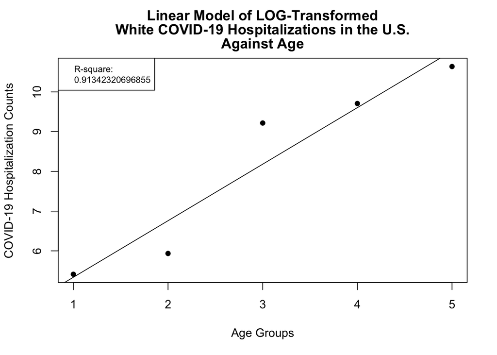

```r
plot(covid_white$Age.Group, log(covid_white$Count), xlab = "Age Groups", ylab = "COVID-19 Hospitalization Counts", main = c("Linear Model of LOG-Transformed", "White COVID-19 Hospitalizations in the U.S.", "Against Age"), pch=16)
abline(coef = coef(covid_white_Lm))
legend("topleft", legend = c("R-square:", w_rsq_lm), cex = 0.75)
```

Figure 2: White covid-19 hospitalizations against age groups. Age groups are: 1 = 0-4 years, 2 = 5-17 years, 3 = 18-49 years, 4 = 50-64 years, 5 = 65+ years.

- For the White race group, our test statistic was **31.6513182** which is larger than our critical value of **7.7086474**. The p-value for the linear model was **0.0111062**, which is smaller than 0.05. This means we have enough evidence to reject the null hypothesis that there is no relationship between age groups and counts. The r-squared value was **0.9134232**, which is a strong, positive linear relationship.

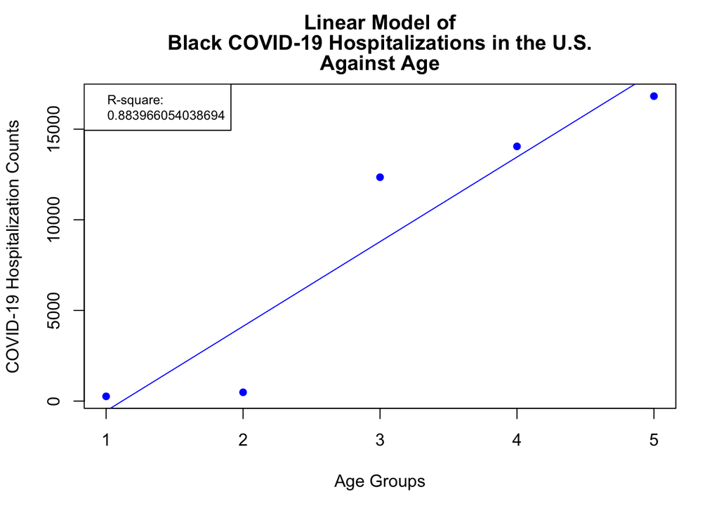

```r
plot(covid_black$Age.Group, covid_black$Count, xlab = "Age Groups", ylab = "COVID-19 Hospitalization Counts", main = c("Linear Model of", "Black COVID-19 Hospitalizations in the U.S.", "Against Age"), pch=16, col = "blue")
abline(coef = coef(covid_black_Lm), col = "blue")
legend("topleft", legend = c("R-square:", b_rsq_lm), cex = 0.75)
```

Figure 3: Black covid-19 hospitalizations against age groups. Age groups are: 1 = 0-4 years, 2 = 5-17 years, 3 = 18-49 years, 4 = 50-64 years, 5 = 65+ years.

- For the Black race group, our test statistic was **22.854503** which is larger than our critical value of **7.7086474**. The p-value for the linear model was **0.0173984**, which is smaller than 0.05. This means we have enough evidence to reject the null hypothesis that there is no relationship between age groups and counts. The r-squared value was **0.8839661**, which is a strong, positive linear relationship.

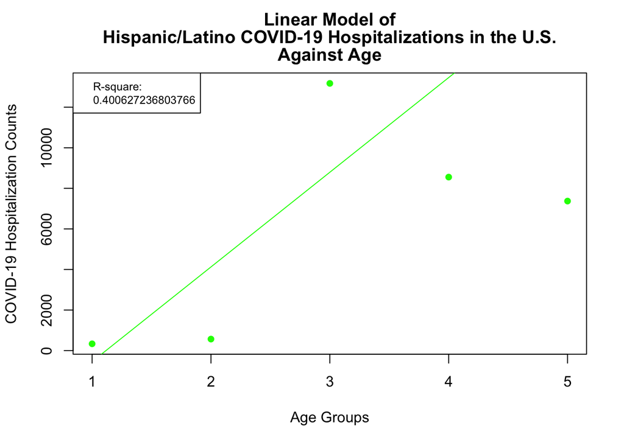

```r
plot(covid_hisplat$Age.Group, covid_hisplat$Count, xlab = "Age Groups", ylab = "COVID-19 Hospitalization Counts", main = c("Linear Model of", "Hispanic/Latino COVID-19 Hospitalizations in the U.S.", "Against Age"), pch=16, col = "green")
abline(coef = coef(covid_black_Lm), col = "green")
legend("topleft", legend = c("R-square:", h_rsq_lm), cex = 0.75)
```

Figure 4: Hispanic/Latino covid-19 hospitalizations against age groups. Age groups are: 1 = 0-4 years, 2 = 5-17 years, 3 = 18-49 years, 4 = 50-64 years, 5 = 65+ years.

- For the Hispanic/Latino race group, our test statistic was **2.0052324** which is smaller than our critical value of **7.7086474**. The p-value for the linear model was **0.2517268**, which is larger than 0.05. This means we do not have enough evidence to reject the null hypothesis that there is no relationship between age groups and counts. The r-squared value was **0.4006272**, which is a very weak, postive linear relationship.

[figure not shown]

```r
plot(covid_aapi$Age.Group, covid_aapi$Count, xlab = "Age Groups", ylab = "COVID-19 Hospitalization Counts", main = c("Linear Model of", "Black COVID-19 Hospitalizations in the U.S.", "Against Age"), pch=16, col = "red")
abline(coef = coef(covid_aapi_Lm), col = "red")
legend("topleft", legend = c("R-square:", asn_rsq_lm), cex = 0.75)
```

Figure 5: Asian/Pacific Islander covid-19 hospitalizations against age groups. Age groups are: 1 = 0-4 years, 2 = 5-17 years, 3 = 18-49 years, 4 = 50-64 years, 5 = 65+ years.

- For the Asian/Pacific Islander race group, our test statistic was **30.004379** which is larger than our critical value of **7.7086474**. The p-value for the linear model was **0.0119645**, which is smaller than 0.05. This means we have enough evidence to reject the null hypothesis that there is no relationship between age groups and counts. The r-squared value was **0.909103**, which is a very strong, positive linear relationship.

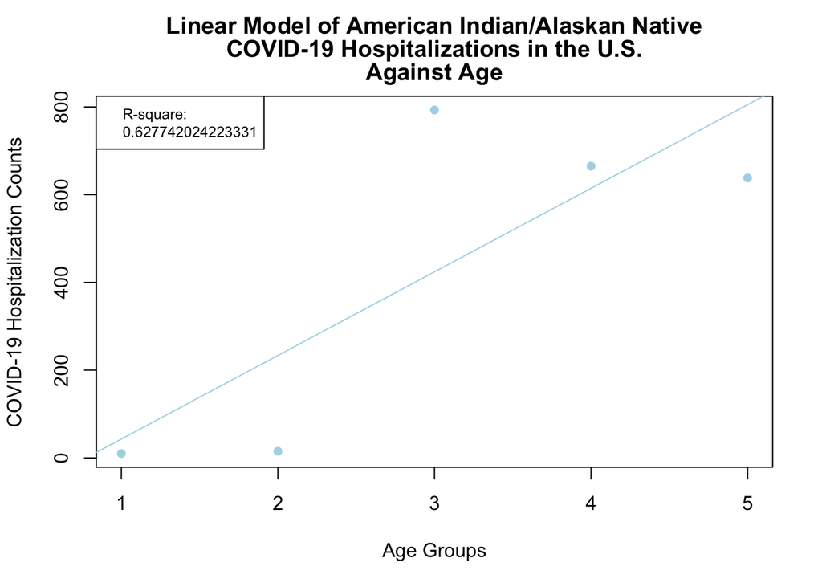

```r
plot(covid_amIn$Age.Group, covid_amIn$Count, xlab = "Age Groups", ylab = "COVID-19 Hospitalization Counts", main = c("Linear Model of American Indian/Alaskan Native", "COVID-19 Hospitalizations in the U.S.", "Against Age"), pch=16, col = "lightblue")
abline(coef = coef(covid_amIn_Lm), col = "lightblue")
legend("topleft", legend = c("R-square:", ami_rsq_lm), cex = 0.75)
```

Figure 6: American Indian/Alaskan Native covid-19 hospitalizations against age groups. Age groups are: 1 = 0-4 years, 2 = 5-17 years, 3 = 18-49 years, 4 = 50-64 years, 5 = 65+ years.

- For the American Indian/Alaskan Native race group, our test statistic was **5.0589274** which is smaller than our critical value of **7.7086474**. The p-value for the linear model was **0.1100189**, which is larger than 0.05. This means we do not have enough evidence to reject the null hypothesis that there is no relationship between age groups and counts. The r-squared value was **0.627742**, which is a weak, positive linear relatinoship.

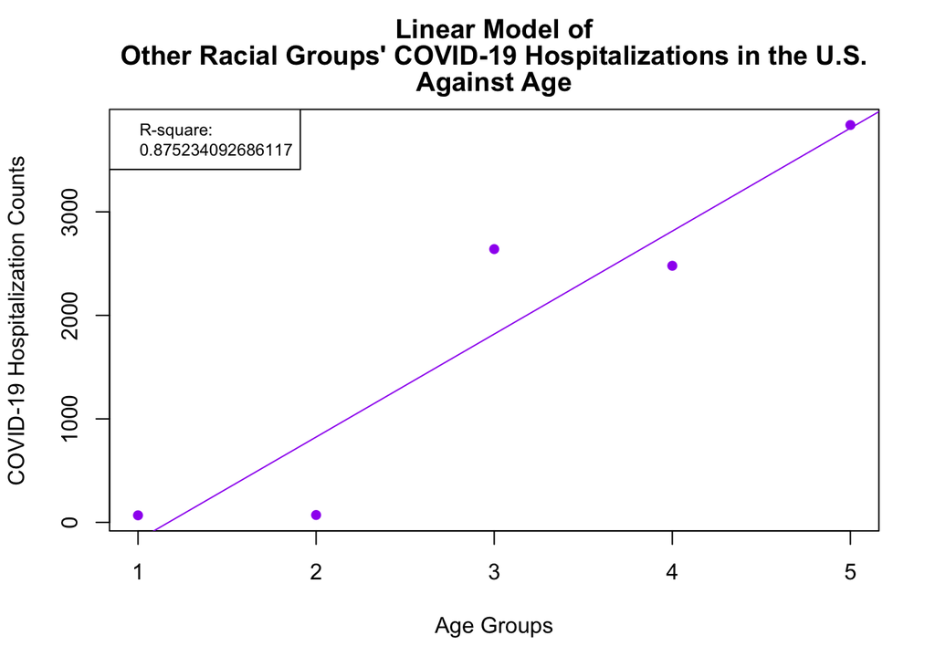

```r
plot(covid_other$Age.Group, covid_other$Count, xlab = "Age Groups", ylab = "COVID-19 Hospitalization Counts", main = c("Linear Model of", "Other Racial Groups' COVID-19 Hospitalizations in the U.S.", "Against Age"), pch=16, col = "purple")
abline(coef = coef(covid_other_Lm), col = "purple")
legend("topleft", legend = c("R-square:", o_rsq_lm), cex = 0.75)
```

Figure 7: Other race groups’ covid-19 hospitalizations against age groups. Age groups are: 1 = 0-4 years, 2 = 5-17 years, 3 = 18-49 years, 4 = 50-64 years, 5 = 65+ years.

- For the “Other” race group, our test statistic was **21.0450301** which is larger than our critical value of **7.7086474**. The p-value for the linear model was **0.019455**, which is smaller than 0.05. This means we have enough evidence to reject the null hypothesis that there is no relationship between age groups and counts. The r-squared value was **0.8752341**, which is a strong, positive linear relationship.

### Works Cited

- Centers for Disease Control and Prevention. Fourth Report on Human Exposure to Environmental Chemicals, COVID-19 Data Tracker, (May 2021). Atlanta, GA: U.S. Department of Health and Human Services, Centers for Disease Control and Prevention. https://gis.cdc.gov/grasp/COVIDNet/COVID19_5.html